# Las Vegas Hotel Reviews Analysis

2018-02-05

[figure not shown]

las_vegas_banner

I would recommend reading this blog post in my github repo las_vegas_hotel_reviews

```python
import sys
print(sys.version)
```

```
3.5.3 |Anaconda 4.4.0 (x86_64)| (default, Mar  6 2017, 12:15:08)
[GCC 4.2.1 Compatible Apple LLVM 6.0 (clang-600.0.57)]
```

```python
# load dependencies
import pandas as pd
import io
import requests
import numpy as np
from scipy import stats
import matplotlib.pyplot as plt
%matplotlib inline

from sklearn.utils import shuffle
from sklearn.neighbors import KNeighborsClassifier
from sklearn.naive_bayes import BernoulliNB
from sklearn.model_selection import train_test_split
from sklearn.ensemble import RandomForestClassifier

from hpsklearn import HyperoptEstimator, any_classifier
from sklearn.datasets import fetch_mldata
from hyperopt import tpe

# reference:
# https://stackoverflow.com/questions/32400867/pandas-read-csv-from-url
```

### Table of Content

1. Goal of This Project
2. Golden Rule of Machine Learning
3. Exploratory Data Analysis (EDA)
4. Reflection of EDA
5. More Data Wrangling
6. kNN Classifier
7. NaiveBayes Classifier
8. Random Forest Classifier

### 1. Goal of This Project

I plan to go to Las Vegas with my undergrad buddies in June 2018. To ensure that we have a good time there, my goal is to find the best features to classify good and bad hotels. I will use my findings help me book a hotel for my trip.

Data Source: [UCI Machine Learning Repository: Las Vegas Strip Data Set](http://archive.ics.uci.edu/ml/datasets/Las+Vegas+Strip)

### 2. Follow the “Golden Rule of Machine Learning”

Retrieve the data set from the source and set a side some data instances as a test set. I will only inspect the training data set.

```python
# load the data
url = "http://archive.ics.uci.edu/ml/machine-learning-databases/00397/LasVegasTripAdvisorReviews-Dataset.csv"
raw_dataframe = pd.read_csv(url, delimiter=';')
# reference:
# https://stackoverflow.com/questions/32400867/pandas-read-csv-from-url/41880513#41880513

# shuffle the array (in case it is sorted)
# https://stackoverflow.com/questions/29576430/shuffle-dataframe-rows
np.random.seed(123)
raw_dataframe = shuffle(raw_dataframe)

# split raw data frame into two sets
training_dataframe = raw_dataframe[:336]
test_datafram = raw_dataframe[336:]

# view the first 2 rows of raw data frame
training_dataframe.head(2)
```

[output not shown]

(too many columns :sad: )

### 3. Exploratory data analysis

I should learn more about the data set then start my feature selection with a deeper understanding of the data set.

```python
training_dataframe.info()

# reference:
# https://github.com/ubcs3/2017-Fall/blob/master/notes-2017-10-06/notes-2017-10-06.ipynb
```

```
<class 'pandas.core.frame.DataFrame'>
Int64Index: 336 entries, 429 to 169
Data columns (total 20 columns):
User country         336 non-null object
Nr. reviews          336 non-null int64
Nr. hotel reviews    336 non-null int64
Helpful votes        336 non-null int64
Score                336 non-null int64
Period of stay       336 non-null object
Traveler type        336 non-null object
Pool                 336 non-null object
Gym                  336 non-null object
Tennis court         336 non-null object
Spa                  336 non-null object
Casino               336 non-null object
Free internet        336 non-null object
Hotel name           336 non-null object
Hotel stars          336 non-null object
Nr. rooms            336 non-null int64
User continent       336 non-null object
Member years         336 non-null int64
Review month         336 non-null object
Review weekday       336 non-null object
dtypes: int64(6), object(14)
memory usage: 55.1+ KB
```

```python
training_dataframe["Hotel name"].value_counts()
```

```
The Palazzo Resort Hotel Casino                        19
The Venetian Las Vegas Hotel                           19
The Cosmopolitan Las Vegas                             19
Trump International Hotel Las Vegas                    19
Bellagio Las Vegas                                     19
Wyndham Grand Desert                                   18
Encore at wynn Las Vegas                               18
The Westin las Vegas Hotel Casino & Spa                18
Wynn Las Vegas                                         17
Caesars Palace                                         16
Excalibur Hotel & Casino                               16
Treasure Island- TI Hotel & Casino                     16
Circus Circus Hotel & Casino Las Vegas                 16
Hilton Grand Vacations at the Flamingo                 15
Monte Carlo Resort&Casino                              14
Hilton Grand Vacations on the Boulevard                14
Paris Las Vegas                                        14
Tropicana Las Vegas - A Double Tree by Hilton Hotel    13
Marriott's Grand Chateau                               12
Tuscany Las Vegas Suites & Casino                      12
The Cromwell                                           12
Name: Hotel name, dtype: int64
```

> Hotels are pretty evenly reviewed by customers.

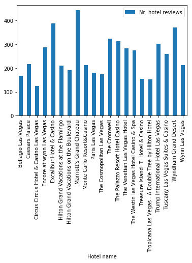

png

```python
training_dataframe.groupby("Hotel name").sum().plot.bar(y="Nr. hotel reviews")
```

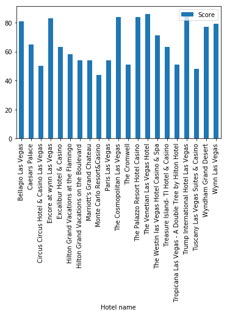

png

```python
training_dataframe.groupby("Hotel name").sum().plot.bar(y="Score")
```

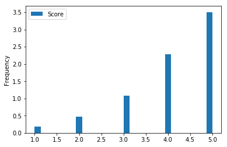

png

```python
training_dataframe.plot.hist(y="Score", bins=30, normed=True)
plt.show()
```

```python
training_dataframe["User country"].value_counts()
```

```
USA             162
UK               45
Canada           37
Australia        23
Ireland          10
India             7
Germany           5
New Zeland        5
Egypt             3
Mexico            3
Malaysia          3
Netherlands       3
Brazil            2
Israel            2
Norway            2
Costa Rica        2
Singapore         2
Finland           2
Scotland          2
Thailand          2
Saudi Arabia      1
Kuwait            1
South Africa      1
Hawaii            1
Italy             1
Switzerland       1
Croatia           1
Kenya             1
Swiss             1
Puerto Rico       1
Spain             1
Taiwan            1
Belgium           1
China             1
Name: User country, dtype: int64
```

> Most of the reviews are done by US customers. They may or may not reflect Canadian taste.

```python
training_dataframe["Traveler type"].value_counts()
```

```
Couples     143
Families     71
Friends      62
Business     44
Solo         16
Name: Traveler type, dtype: int64
```

> Most of the reviews are done by couples. My group is not in this category. We are in the “friends” category.

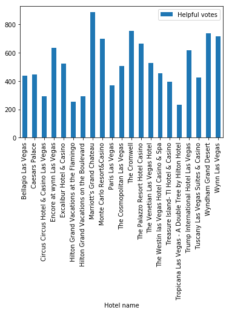

png

```python
training_dataframe.groupby("Hotel name").sum().plot.bar(y="Helpful votes")
plt.show()
```

> Reviews of “Marriott’s Grand Chateau” received the most helpful votes.

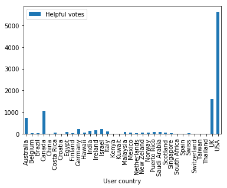

png

```python
training_dataframe.groupby("User country").sum().plot.bar(y="Helpful votes")
plt.show()
```

> Reviews submitted by US, UK, Canadian, and Australian customers received the most helpful votes.